# IMDB

To connect to the database,

```r
#library(RMySQL)
#drv = dbDriver("MySQL")
#con = dbConnect(drv, dbname = 'imdb', user = 'imdb', password = 'imdb',host = 'radagast.berkeley.edu')
#dbListTables(con)
```

```r
library(RSQLite)
drv = dbDriver("SQLite")
con = dbConnect(drv, dbname = "~/Downloads/lean_imdbpy_2010.db")
dbListTables(con)
```

```
##  [1] "aka_name2"       "aka_title2"      "cast_info2"
##  [4] "info_type"       "keyword2"        "kind_type"
##  [7] "movie_info2"     "movie_info_idx2" "movie_keyword2"
## [10] "name2"           "person_info2"    "role_type"
## [13] "sqlite_sequence" "title2"
```

```r
dbListFields(con, "cast_info2")
```

```
## [1] "id"             "person_id"      "movie_id"       "person_role_id"
## [5] "note"           "nr_order"       "role_id"
```

Answer the following 5 questions. In addition, there is 1 bonus question that you can use to improve one of your HW scores or lab scores by 1 point.

## What proportion of the actors are female?

Assign your answer to ‘propF’

```r
dbListFields(con, "name2")
```

```
## [1] "id"            "name"          "imdb_index"    "imdb_id"
## [5] "gender"        "name_pcode_cf" "name_pcode_nf" "surname_pcode"
## [9] "md5sum"
```

```r
propF_df = dbGetQuery(con, "SELECT gender, COUNT(*) as count FROM name2 WHERE gender = 'f' or gender = 'm' GROUP BY gender;")
total = propF_df[propF_df$gender == 'f', 2] + propF_df[propF_df$gender == 'm', 2]
propF = propF_df[propF_df$gender == 'f', 2]/total
```

## How many movies are there in the database?

Assign your answer to ‘numMovies’. Note that by movies, we mean that they are actual movies and not television series, etc.

```r
numMovies_df = dbGetQuery(con, "SELECT COUNT(*) FROM title2 WHERE kind_id = 1;")
numMovies = numMovies_df[1,1]
```

## Long-Running TV Series

List the 5 longest running television series (number of seasons). Include the number of episodes as `numEp`, number of seasons as `numSe`, and name of each series as `title`. Your answer should be in a data frame called `longRun`

```r
library(RMySQL)
drv = dbDriver("MySQL")
con = dbConnect(drv, dbname = 'imdb', user = 'imdb', password = 'imdb',
                host = 'radagast.berkeley.edu')
dbListTables(con)
```

```
##  [1] "aka_name"        "aka_title"       "cast_info"
##  [4] "char_name"       "comp_cast_type"  "company_name"
##  [7] "company_type"    "complete_cast"   "info_type"
## [10] "keyword"         "kind_type"       "link_type"
## [13] "movie_companies" "movie_info"      "movie_info_idx"
## [16] "movie_keyword"   "movie_keyword2"  "movie_link"
## [19] "name"            "person_info"     "role_type"
## [22] "title"           "title2"
```

```r
longRun = dbGetQuery(con, "SELECT a.title, b.season_nr as numSe, b.episode_nr as numEp FROM title AS a, title as b WHERE a.kind_id = 2 AND b.kind_id = 7 AND b.season_nr < 210 AND a.id = b.episode_of_id GROUP BY a.title ORDER BY numSe DESC LIMIT 5;")
```

## Has the number of movies in the horror genre changed over time?

Plot the overall number of movies in each year over time. Be sure to make your plot relative to the number movies produced each year.

```r
library(RSQLite)
drv = dbDriver("SQLite")
con = dbConnect(drv, dbname = "~/Downloads/lean_imdbpy_2010.db")
dbListTables(con)
```

```
##  [1] "aka_name2"       "aka_title2"      "cast_info2"
##  [4] "info_type"       "keyword2"        "kind_type"
##  [7] "movie_info2"     "movie_info_idx2" "movie_keyword2"
## [10] "name2"           "person_info2"    "role_type"
## [13] "sqlite_sequence" "title2"
```

```r
dbListFields(con, "cast_info2")
```

```
## [1] "id"             "person_id"      "movie_id"       "person_role_id"
## [5] "note"           "nr_order"       "role_id"
```

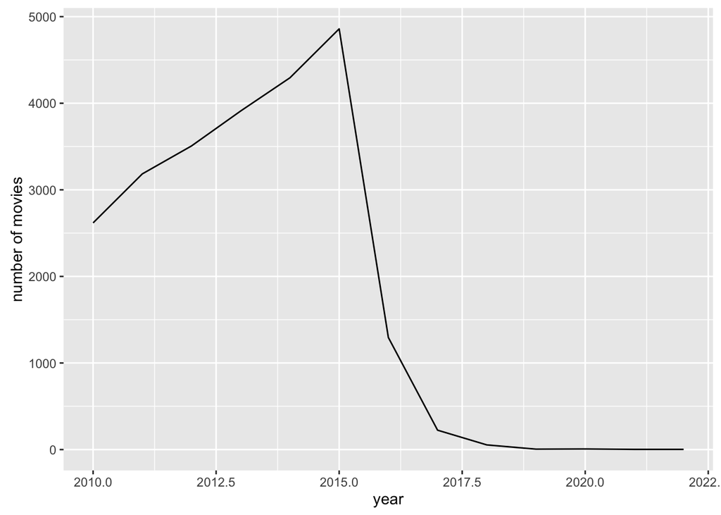

```r
library(ggplot2)
horror_df = dbGetQuery(con,
  "SELECT t.production_year as year, COUNT(t.production_year) as count FROM title2 AS t
    INNER JOIN movie_info2 on t.id = movie_info2.movie_id
    WHERE info_type_id = 3 and info = 'Horror'
    GROUP BY t.production_year;")

ggplot(data = horror_df, aes(horror_df$year, horror_df$count)) + geom_line() + xlab("year") + ylab("number of movies")
```

## Who are the actors that have been in the most movies?

List the top 20 actors with their names and the count of movies. Store this information in the data frame called `top20` with the actor’s name in `name` and the count in `numM`.

```r
top20 = dbGetQuery(con,
  "SELECT name2.name as name, COUNT(name) as numM FROM cast_info2
     INNER JOIN name2 ON cast_info2.person_id = name2.id
     WHERE role_id = 1 or role_id = 2
     GROUP BY name
     ORDER BY numM DESC
     LIMIT 20;")
```

## Challenge Networks

Pick a (lead) actor who has been in at least 20 movies. Find all of the other actors that have appeared in a movie with that person. For each of these, find all the people they have appeared in a move with him/her.

Use this to create a network/graph of who has appeared with who. Use the `igraph` or `statnet` packages to display this network.

Try doing this with individual SQL commands and the process the results in R to generate new SQL queries. In other words, don’t spend too much time trying to create clever SQL queries as there is a more direct way to do this in R.

[output not shown]

[output cut: 544 more lines]

[output not shown]

[figure not shown]

```r
library(igraph)
findCastPloting = function(movie_ids){
  result = NA
  edges = c()
  for(movie_id in movie_ids) {
    query = paste("SELECT t.title AS title, c.person_id AS person_id, name2.name AS name FROM title2 AS t, cast_info2 AS c, name2 WHERE t.id =", movie_id, "AND t.id = c.movie_id AND name2.id = c.person_id AND (c.role_id = 1 OR c.role_id = 2);")
    title_person_df = dbGetQuery(con,  query)
    persons = title_person_df$name
    for(name1 in persons) {
      for(name2 in persons) {
        if(name1 != name2){
          edges = c(edges, name1, name2)
        }
      }
    }
    if(is.na(result))
      result = title_person_df
    else
      result = rbind(result, title_person_df)
  }
  # make network
  network = graph(edges)
  plot(network)
  return(result)
}


name = 'Brahmanandam'
person_id_query = paste("SELECT id FROM name2 AS n WHERE n.name = \'", name, "\';", sep = "")
person_id_df = dbGetQuery(con, person_id_query)
person_id = person_id_df[1,1]
movie_id_query = paste("SELECT movie_id FROM cast_info2 WHERE person_id =", person_id, ";")
movie_ids_df = dbGetQuery(con, movie_id_query)
movie_ids = movie_ids_df[ ,1]
connection_df = findCastPloting(movie_ids)
```